# Assignment: Local (alpha) Diversity

Evgeniya Polezhaeva Z620: Quantitative Biodiversity, Indiana University

## OVERVIEW

In this exercise, we will explore aspects of local or site-specific diversity, also known as alpha ($\alpha$) diversity. First we will quantify two of the fundamental components of ($\alpha$) diversity: **richness** and **evenness**. From there, we will then discuss ways to integrate richness and evenness, which will include univariate metrics of diversity along with an investigation of the **species abundance distribution (SAD)**.

## Directions:

1. Change “Student Name” on line 3 (above) with your name.
2. Complete as much of the exercise as possible during class; what you do not complete in class will need to be done on your own outside of class.
3. Use the handout as a guide; it contains a more complete description of data sets along with the proper scripting needed to carry out the exercise.
4. Be sure to **answer the questions** in this exercise document; they also correspond to the handout. Space for your answer is provided in this document and indicated by the “>” character. If you need a second paragraph be sure to start the first line with “>”.
5. Before you leave the classroom, **push** this file to your GitHub repo.
6. For homework, follow the directions at the bottom of this file.
7. When you are done, **Knit** the text and code into a PDF file.
8. After Knitting, please submit the completed exercise by creating a **pull request** via GitHub. Your pull request should include this file `alpha_assignment.Rmd` and the PDF output of `Knitr` (`alpha_assignment.pdf`).

## 1) R SETUP

In the R code chunk below, please provide the code to: 1) Clear your R environment, 2) Print your current working directory, 3) Set your working directory to your `/Week2-Alpha` folder, and 4) Load the `vegan` R package (be sure to install if needed).

```r
rm(list=ls())
getwd()
```

```
## [1] "D:/Jane/GitHub/QB2017_Polezhaeva/Week2-Alpha"
```

```r
setwd("D:/Jane/GitHub/QB2017_Polezhaeva/Week2-Alpha")
getwd()
```

```
## [1] "D:/Jane/GitHub/QB2017_Polezhaeva/Week2-Alpha"
```

```r
install.packages("vegan", repos="http://cran.rstudio.com/")
require("vegan")
```

## 2) LOADING DATA

In the R code chunk below, do the following: 1) Load your dataset, and 2) Display the structure of the dataset (if the structure is long, use `max.level=0` to show just basic information).

```r
require("vegan")
data(BCI)
typeof(BCI)
```

```
## [1] "list"
```

```r
str(BCI)
```

```
## 'data.frame':    50 obs. of  225 variables:
##  $ Abarema.macradenia              : int  0 0 0 0 0 0 0 0 0 1 ...
##  $ Vachellia.melanoceras           : int  0 0 0 0 0 0 0 0 0 0 ...
##  $ Acalypha.diversifolia           : int  0 0 0 0 0 0 0 0 0 0 ...
##  $ Acalypha.macrostachya           : int  0 0 0 0 0 0 0 0 0 0 ...
##  $ Adelia.triloba                  : int  0 0 0 3 1 0 0 0 5 0 ...
##  $ Aegiphila.panamensis            : int  0 0 0 0 1 0 1 0 0 1 ...
##  $ Alchornea.costaricensis         : int  2 1 2 18 3 2 0 2 2 2 ...
##  $ Alchornea.latifolia             : int  0 0 0 0 0 1 0 0 0 0 ...
##  $ Alibertia.edulis                : int  0 0 0 0 0 0 0 0 0 0 ...
##  $ Allophylus.psilospermus         : int  0 0 0 0 1 0 0 0 0 0 ...
##  $ Alseis.blackiana                : int  25 26 18 23 16 14 18 14 16 14 ...
##  $ Amaioua.corymbosa               : int  0 0 0 0 0 0 0 0 0 0 ...
##  $ Anacardium.excelsum             : int  0 0 0 0 0 0 0 1 0 0 ...
##  $ Andira.inermis                  : int  0 0 0 0 1 1 0 0 1 0 ...
```

[output cut: 87 more lines]

## 3) SPECIES RICHNESS

**Species richness (S)** is simply the number of species in a system or the number of species observed in a sample.

### Observed Richness

In the R code chunk below, do the following:

1. Write a function called `S.obs` to calculate observed richness
2. Use your function to determine the number of species in `site1`, and
3. Compare the output of your function to the output of the `specnumber()` function in vegan.

```r
S.obs <- function(x = ""){rowSums(x>0) * 1}
site1 <- BCI[1,]
site1
```

```
##   Abarema.macradenia Vachellia.melanoceras Acalypha.diversifolia
## 1                  0                     0                     0
##   Acalypha.macrostachya Adelia.triloba Aegiphila.panamensis
## 1                     0              0                    0
##   Alchornea.costaricensis Alchornea.latifolia Alibertia.edulis
## 1                       2                   0                0
##   Allophylus.psilospermus Alseis.blackiana Amaioua.corymbosa
## 1                       0               25                 0
##   Anacardium.excelsum Andira.inermis Annona.spraguei Apeiba.glabra
## 1                   0              0               1            13
##   Apeiba.tibourbou Aspidosperma.desmanthum Astrocaryum.standleyanum
## 1                2                       0                        0
##   Astronium.graveolens Attalea.butyracea Banara.guianensis
## 1                    6                 0                 0
##   Beilschmiedia.pendula Brosimum.alicastrum Brosimum.guianense
## 1                     4                   5                  0
##   Calophyllum.longifolium Casearia.aculeata Casearia.arborea
## 1                       0                 0                1
##   Casearia.commersoniana Casearia.guianensis Casearia.sylvestris
## 1                      0                   0                   2
##   Cassipourea.guianensis Cavanillesia.platanifolia Cecropia.insignis
## 1                      2                         0                12
##   Cecropia.obtusifolia Cedrela.odorata Ceiba.pentandra Celtis.schippii
## 1                    0               0               0               0
##   Cespedesia.spathulata Chamguava.schippii Chimarrhis.parviflora
## 1                     0                  0                     0
##   Maclura.tinctoria Chrysochlamys.eclipes Chrysophyllum.argenteum
## 1                 0                     0                       4
##   Chrysophyllum.cainito Coccoloba.coronata Coccoloba.manzinellensis
## 1                     0                  0                        0
##   Colubrina.glandulosa Cordia.alliodora Cordia.bicolor Cordia.lasiocalyx
## 1                    0                2             12                 8
##   Coussarea.curvigemma Croton.billbergianus Cupania.cinerea
## 1                    0                    2               0
##   Cupania.latifolia Cupania.rufescens Cupania.seemannii
## 1                 0                 0                 2
##   Dendropanax.arboreus Desmopsis.panamensis Diospyros.artanthifolia
## 1                    0                    0                       1
##   Dipteryx.oleifera Drypetes.standleyi Elaeis.oleifera
## 1                 1                  2               0
```

[output cut: 83 more lines]

```
## 1               0                 0                    3               0
##   Trichanthera.gigantea Trichilia.pallida Trichilia.tuberculata
## 1                     0                 0                    18
##   Trichospermum.galeottii Triplaris.cumingiana Trophis.caucana
## 1                       0                    0               2
##   Trophis.racemosa Turpinia.occidentalis Unonopsis.pittieri
## 1                1                     0                  1
##   Virola.multiflora Virola.sebifera Virola.surinamensis Vismia.baccifera
## 1                 0              17                   4                0
##   Vochysia.ferruginea Xylopia.macrantha Zanthoxylum.ekmanii
## 1                   0                 1                   3
##   Zanthoxylum.juniperinum Zanthoxylum.panamense Zanthoxylum.setulosum
## 1                       0                     2                     0
##   Zuelania.guidonia
## 1                 0
```

```r
S.obs(site1)
```

```
##  1
## 93
```

```r
require("vegan")
specnumber(site1)
```

```
##  1
## 93
```

```r
specnumber(BCI[1:4,])
```

```
##  1  2  3  4
## 93 84 90 94
```

```r
# S.obs <- function(   ){
#   rowSums(     ) *
#   }
```

*Question 1*: Does `specnumber()` from `vegan` return the same value for observed richness in `site1` as our function `S.obs`? What is the species richness of the first 4 sites (i.e., rows) of the BCI matrix?

> *Answer 1*: Yes, it does. The species richness of the first 4 sites: 93, 84, 90, 94

### Coverage. How Well Did You Sample Your Site?

In the R code chunk below, do the following:

1. Write a function to calculate Good’s Coverage, and
2. Use that function to calculate coverage for all sites in the BCI matrix.

```r
C <- function(x = ""){(1 - sum(x == 1)/rowSums(x))}
C(BCI[1,])
```

```
##         1
## 0.9308036
```

```r
n_row <- nrow(BCI)
C_BCI <- c()
for (i in 1:n_row){
  C_BCI[i] <- C(BCI[i,])
}
C_BCI[]
```

```
##  [1] 0.9308036 0.9287356 0.9200864 0.9468504 0.9287129 0.9174757 0.9326923
##  [8] 0.9443155 0.9095355 0.9275362 0.9152120 0.9071038 0.9242054 0.9132420
## [15] 0.9350649 0.9267735 0.8950131 0.9193084 0.8891455 0.9114219 0.8946078
## [22] 0.9066986 0.8705882 0.9030612 0.9095023 0.9115479 0.9088729 0.9198966
## [29] 0.8983516 0.9221053 0.9382423 0.9411765 0.9220183 0.9239374 0.9267887
## [36] 0.9186047 0.9379310 0.9306488 0.9268868 0.9386503 0.8880597 0.9299517
## [43] 0.9140049 0.9168704 0.9234234 0.9348837 0.8847059 0.9228916 0.9086651
## [50] 0.9143519
```

*Question 2*: Answer the following questions about coverage:

1. What is the range of values that can be generated by Good’s Coverage?
2. What would we conclude from Good’s Coverage if $n_{i}$ equaled *N*?
3. What portion of taxa in `site1` were represented by singletons?
4. Make some observations about coverage at the BCI plots.

> *Answer 2a*: from 0 to 1

> *Answer 2b*: C = 0, Coverage = 0%.Data from this site is biased.

> *Answer 2c*: 6.92%

### Estimated Richness

In the R code chunk below, do the following:

1. Load the microbial dataset (located in the `/Week2-Alpha/data` folder),
2. Transform and transpose the data as needed (see handout),
3. Create a vector (`soilbac1`) with the bacterial OTU abundances at any site in the dataset,
4. Calculate the observed richness at that particular site, and
5. Calculate the coverage at that particular site

```r
soilbac <- read.table("data/soilbac.txt", sep = "\t", header = TRUE, row.names = 1)
soilbac.t <- as.data.frame(t(soilbac))
soilbac1 <- soilbac.t[1,]
soilbac1
```

[output not shown]

[output cut: 1949 more lines]

[output not shown]

```r
S.obs(soilbac1)
```

```
## T1_1
## 1074
```

```r
C(soilbac1)
```

```
##      T1_1
## 0.6479471
```

*Question 3*: Answer the following questions about the soil bacterial dataset.

1. How many sequences did we recover from the sample `soilbac1`, i.e. *N*?
2. What is the observed richness of `soilbac1`?
3. How does coverage compare between the BCI sample (`site1`) and the KBS sample (`soilbac1`)?

> *Answer 3b*: 1074

> *Answer 3c*: C(soilbac1) = 64.8%; C(site1) =93.1% Coverage of BCI sample is better than one of KBS sample.

### Richness Estimators

In the R code chunk below, do the following:

1. Write a function to calculate **Chao1**,
2. Write a function to calculate **Chao2**,
3. Write a function to calculate **ACE**, and
4. Use these functions to estimate richness at both `site1` and `soilbac1`.

```r
S.chao1 <- function(x = ""){S.obs(x) + (sum(x==1)^2) / (2 * sum(x==2))}

S.chao2 <- function(site = "", SbyS = ""){
  SbyS = as.data.frame(SbyS)
  x = SbyS[site, ]
  SbyS.pa <- (SbyS > 0) * 1 # convert the SbyS to presence/absence
  Q1 = sum(colSums(SbyS.pa) ==1)
  Q2 = sum(colSums(SbyS.pa) ==2)
  S.chao2 = S.obs(x) + (Q1^2)/(2 * Q2)
  return(S.chao2)}

S.ace <- function(x = "", thresh = 10){
  x <- x[x>0] # excludes zero-abundance taxa
  S.abund <- length(which(x > thresh)) # richness of abundant taxa
  S.rare <- length(which(x <= thresh)) # richness of rare taxa
  singlt <- length(which(x == 1)) # number of singleton taxa
  N.rare <- sum(x[which(x <= thresh)]) # abundance of rare individuals
  C.ace <- 1 - (singlt / N.rare) # coverage (prop non-singlt rare inds)
  i <- c(1:thresh) # threshold abundance range
  count <- function(i, y){ # counter to go through i range
  length(y[y == i])}
  a.1 <- sapply(i, count, x) # number of individuals in richness i richness classes
  f.1 <- (i * (i - 1)) * a.1 # k(k-1)kf sensu Gotelli
  G.ace <- (S.rare/C.ace)*(sum(f.1)/(N.rare*(N.rare-1)))
  S.ace <- S.abund + (S.rare/C.ace) + (singlt/C.ace) * max(G.ace,0)
  return(S.ace)
}
S.chao1(site1)
```

```
##        1
## 119.6944
```

```r
S.chao2(1, BCI)
```

```
##        1
## 104.6053
```

```r
S.ace(site1)
```

```
## [1] 159.3404
```

```r
S.chao1(soilbac1)
```

```
##     T1_1
## 2628.514
```

```r
S.chao2(1, soilbac.t)
```

```
##     T1_1
## 21055.39
```

```r
S.ace(soilbac1)
```

```
## [1] 4465.983
```

### Rarefaction

In the R code chunk below, please do the following:

1. Calculate observed richness for all samples in `soilbac`,
2. Determine the size of the smallest sample,
3. Use the `rarefy()` function to rarefy each sample to this level,
4. Plot the rarefaction results, and
5. Add the 1:1 line and label.

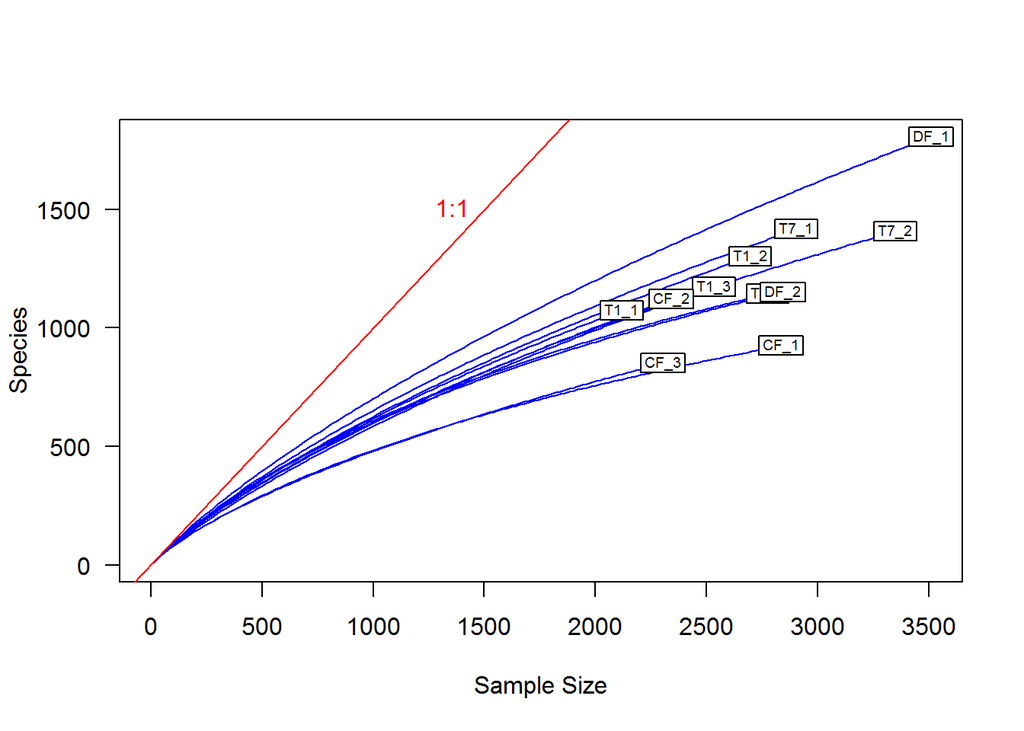

```r
soilbac.S <- S.obs(soilbac.t)
min.N <- min(rowSums(soilbac.t))
S.rarefy <- rarefy(x = soilbac.t, sample = min.N, se = TRUE)
rarecurve(x = soilbac.t, step = 20, col = "blue", cex = 0.6, las=1)
abline(0, 1, col = 'red')
text(1500, 1500, "1:1", pos = 2, col = 'red')
```

*Question 4*: What is the difference between ACE and the Chao estimators?

> *Answer 4*: Chao estimaters take into account only singltons and doubletons while ACE estimator considers abundance of rare species (species detected less than ‘threshold’ times).

## 4) SPECIES EVENNESS

Here, we consider how abundance varies among species, that is, **species evenness**.

### Visualizing Evenness: The Rank Abundance Curve (RAC)

One of the most common ways to visualize evenness is in a **rank-abundance curve** (sometime referred to as a rank-abundance distribution or Whittaker plot). An RAC can be constructed by ranking species from the most abundant to the least abundant without respect to species labels (and hence no worries about ‘ties’ in abundance).

In the R code chunk below, do the following:

1. Write a function to construct a RAC,
2. Be sure your function removes species that have zero abundances,
3. Order the vector (RAC) from greatest (most abundant) to least (least abundant), and
4. Return the ranked vector

```r
RAC <- function(x = ""){
  x = as.vector(x)
  x.ab = x[x > 0]
  x.ab.ranked = x.ab[order(x.ab, decreasing = TRUE)]
  return(x.ab.ranked)}
```

Now, let’s examine the RAC for `site1` of the BCI data set.

In the R code chunk below, do the following:

1. Create a sequence of ranks and plot the RAC with natural-log-transformed abundances,
2. Label the x-axis “Rank in abundance” and the y-axis “log(abundance)”

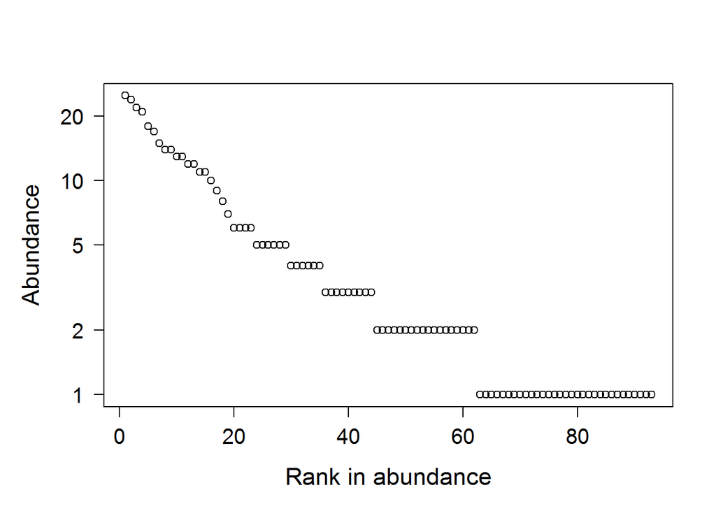

```r
rac <- RAC(x = site1)
ranks <- as.vector(seq(1, length(rac)))
opar <- par(no.readonly = TRUE)                       # Saves default plot parameters

par(mar = c(5.1, 5.1, 4.1, 2.1))                      # New settings for par
plot(ranks, log(rac), type = 'p', axes = F,           # Plots w/o axes
  xlab = "Rank in abundance", ylab = "Abundance",
  las = 1, cex.lab = 1.4, cex.axis = 1.25)
box()                                                  # Manually adds border
axis(side = 1, labels = T, cex.axis = 1.25)            # Manually adds X-axis
axis(side = 2, las = 1, cex.axis = 1.25,               # Manually adds Log-Scaled Y-axis
labels = c(1, 2, 5, 10, 20), at = log(c(1, 2, 5, 10, 20)))
```

*Question 5*: What effect does visualizing species abundance data on a log-scaled axis have on how we interpret evenness in the RAC?

> *Answer 5*: Species abundance data are more convenient to perceive if log-scaled axis is used.

Now that we have visualized unevennes, it is time to quantify it using Simpson’s evenness ($E_{1/D}$) and Smith and Wilson’s evenness index ($E_{var}$).

### Simpson’s evenness ($E_{1/D}$)

In the R code chunk below, do the following:

1. Write the function to calculate $E_{1/D}$, and
2. Calculate $E_{1/D}$ for `site1`.

```r
SimpE <- function(x = ""){
  S <- S.obs(x)
  x = as.data.frame(x)
  D <- diversity(x, "inv")
  E <- (D)/S
  return(E)}
SimpE(site1)
```

```
##         1
## 0.4238232
```

### Smith and Wilson’s evenness index ($E_{var}$)

In the R code chunk below, please do the following:

1. Write the function to calculate $E_{var}$,
2. Calculate $E_{var}$ for `site1`, and
3. Compare $E_{1/D}$ and $E_{var}$.

```r
Evar <- function(x){
  x <- as.vector(x [x > 0])
  1 - (2/pi)*atan(var(log(x)))}

Evar(site1)
```

```
## [1] 0.5067211
```

```r
DeltaEvenness = Evar(site1) - SimpE(site1)
DeltaEvenness
```

```
##          1
## 0.08289795
```

*Question 6*: Compare estimates of evenness for `site1` of BCI using $E_{1/D}$ and $E_{var}$. Do they agree? If so, why? If not, why? What can you infer from the results.

> *Answer 6*: $E_{1/D}$ is close but not equal to $E_{var}$ (lower by 20%). $E_{var}$ decreases input of more abundant species comparing to $E_{1/D}$.

## 5) INTEGRATING RICHNESS AND EVENNESS: DIVERSITY METRICS

So far, we have introduced two primary aspects of diversity, i.e., richness and evenness. Here, we will use popular indices to estimate diversity, which explicitly incorporate richness and evenness We will write our own diversity functions and compare them against the functions in `vegan`.

### Shannon’s diversity (a.k.a., Shannon’s entropy)

In the R code chunk below, please do the following:

1. Provide the code for calculating H’ (Shannon’s diversity),
2. Compare this estimate with the output of `vegan`’s diversity function using method = “shannon”.

```r
ShanH <- function(x = ""){
  H = 0
  for (n_i in x){
    if(n_i > 0) {
      p = n_i / sum(x)
      H = H - p*log(p)}}
  return(H)}

ShanH(site1)
```

```
## [1] 4.018412
```

```r
diversity(site1, index = "shannon")
```

```
## [1] 4.018412
```

### Simpson’s diversity (or dominance)

In the R code chunk below, please do the following:

1. Provide the code for calculating D (Simpson’s diversity),
2. Calculate both the inverse (1/D) and 1 - D,
3. Compare this estimate with the output of `vegan's` diversity function using method = “simp”.

```r
SimpD <- function(x = ""){
  D = 0
  N = sum(x)
  for (n_i in x){
    D = D + (n_i^2)/(N^2)}
  return(D)}

D.inv <- 1/SimpD(site1)
D.sub <- 1-SimpD(site1)

print(D.inv)
```

```
## [1] 39.41555
```

```r
print(D.sub)
```

```
## [1] 0.9746293
```

```r
diversity(site1, "inv")
```

```
## [1] 39.41555
```

```r
diversity(site1, "simp")
```

```
## [1] 0.9746293
```

*Question 7*: Compare estimates of evenness for `site1` of BCI using $E_{H'}$ and $E_{var}$. Do they agree? If so, why? If not, why? What can you infer from the results.

> *Answer 7*: It is Question 6. *Answer 7*: “vegan”s diversity functions return the same values as functions SimpD

### Fisher’s $\boldsymbol\alpha$

In the R code chunk below, please do the following:

1. Provide the code for calculating Fisher’s $\boldsymbol\alpha$,
2. Calculate Fisher’s $\boldsymbol\alpha$ for `site1` of BCI.

```r
rac <- as.vector(site1[site1 > 0])

invD <- diversity(rac, "inv")
invD
```

```
## [1] 39.41555
```

```r
Fisher <- fisher.alpha(rac)
Fisher
```

```
## [1] 35.67297
```

*Question 8*: How is Fisher’s $\boldsymbol\alpha$ different from $E_{H'}$ and $E_{var}$? What does Fisher’s $\boldsymbol\alpha$ take into account that $E_{H'}$ and $E_{var}$ do not?

> *Answer 8*:Fisher’s alpha is fitetd parameter in model for the RAC, diversity metrics (takes into account both richness and evenness), while E(H’) and Evar are measures of evenness.

## 6) MOVING BEYOND UNIVARIATE METRICS OF $\alpha$ DIVERSITY

The diversity metrics that we just learned about attempt to integrate richness and evenness into a single, univariate metric. Although useful, information is invariably lost in this process. If we go back to the rank-abundance curve, we can retrieve additional information – and in some cases – make inferences about the processes influencing the structure of an ecological system.

## Species abundance models

The RAC is a simple data structure that is both a vector of abundances. It is also a row in the site-by-species matrix (minus the zeros, i.e., absences).

Predicting the form of the RAC is the first test that any biodiversity theory must pass and there are no less than 20 models that have attempted to explain the uneven form of the RAC across ecological systems.

In the R code chunk below, please do the following:

1. Use the `radfit()` function in the `vegan` package to fit the predictions of various species abundance models to the RAC of `site1` in BCI,
2. Display the results of the `radfit()` function, and
3. Plot the results of the `radfit()` function using the code provided in the handout.

```r
RACresults <- radfit(site1)
print(RACresults)
```

```
##
## RAD models, family poisson
## No. of species 93, total abundance 448
##
##            par1      par2     par3    Deviance AIC      BIC
## Null                                   39.5261 315.4362 315.4362
## Preemption  0.042797                   21.8939 299.8041 302.3367
## Lognormal   1.0687    1.0186           25.1528 305.0629 310.1281
## Zipf        0.11033  -0.74705          61.0465 340.9567 346.0219
## Mandelbrot  100.52   -2.312    24.084   4.2271 286.1372 293.7350
```

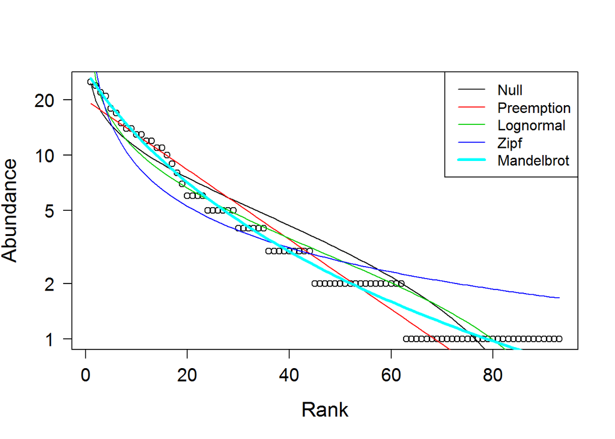

```r
plot.new()
plot(RACresults, las = 1, cex.lab = 1.4, cex.axis = 1.25)
```

*Question 9*: Answer the following questions about the rank abundance curves: a) Based on the output of `radfit()` and plotting above, discuss which model best fits our rank-abundance curve for `site1`? b) Can we make any inferences about the forces, processes, and/or mechanisms influencing the structure of our system, e.g., an ecological community?

*Question 10*: Answer the following questions about the preemption model: a. What does the preemption model assume about the relationship between total abundance (*N*) and total resources that can be preempted? b. Why does the niche preemption model look like a straight line in the RAD plot?

> *Answer 10a*: The more resources that can be preemted (the the same alpha) the higher is total abundance. *Answer 10b*: It represents exponential equation

*Question 11*: Why is it important to account for the number of parameters a model uses when judging how well it explains a given set of data?

> *Answer 11*: The higher number of parameters the easier (usually) to find those which will better describe data.

## SYNTHESIS

1. As stated by Magurran (2004) the ${D = } \sum p_i^2$ derivation of Simpson’s Diversity only applies to communities of infinite size. For anything but an infinitely large community, Simpson’s Diversity index is calculated as ${D = } \sum \frac{n_i(n_i -1)} {N(N-1)}$. Assuming a finite community, calculate Simpson’s D, 1 - D, and Simpson’s inverse (i.e. 1/D) for `site 1` of the BCI site-by-species matrix.

2. Along with the rank-abundance curve (RAC), another way to visualize the distribution of abundance among species is with a histogram (a.k.a., frequency distribution) that shows the frequency of different abundance classes.

For example, in a given sample, there may be 10 species represented by a single individual, 8 species with two individuals, 4 species with three individuals, and so on. In fact, the rank-abundance curve and the frequency distribution are the two most common ways to visualize the species-abundance distribution (SAD) and to test species abundance models and biodiversity theories. To address this homework question, use the R function **hist()** to plot the frequency distribution for `site 1` of the BCI site-by-species matrix, and describe the general pattern you see.

3. We asked you to find a biodiversity dataset with your partner. This data could be one of your own or it could be something that you obtained from the literature. Load that dataset.

## SUBMITTING YOUR ASSIGNMENT

Use Knitr to create a PDF of your completed alpha_assignment.Rmd document, push it to GitHub, and create a pull request. Please make sure your updated repo include both the HTML and RMarkdown files.